# act_report

## Report: act_report

### By Ayame God'swill Claude

### Insights:

```
Analysis and visualization is one crucial but interesting part of the job of a Data Analyst. After gathering, assessing and cleaning our dataset, we try to look for insights - depending on what exactly we are trying to find or discover.

Upon examining my cleaned master dataset, I decided to come up with the following insights:
```

Insight #1: Which dog stage has the highest number of tweets by tweeter users?

THE RESULT? I found out that pupper (a small doggo usually younger, inexperienced, unfamiliar and not ready for the responsibilities of being a doggo) has the highest number of likes or favourites. This comes as no surprise to me because people are naturally drawn to smaller, younger dogs - maybe because at this stage the dogs are usually more or less harmless and, more so, they can nuture them to adulthood and form a bond with them in the process

The visualization below shows clearly communicates the results

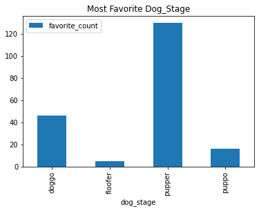

Insight #2: Which rating numerator of dogs occurs most frequently?

THE RESULT? 12 is the most frequently occuring dog rating numerator. This suggests that most persons are rather conservative with the rating of dogs. It would take an exceptional dog tweet to get a higher rating.

The accompanying visualization is shown below

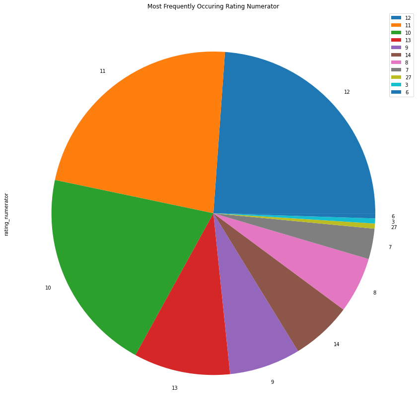

Insight #3: Does the stage of a dog determine the number of retweets by tweeter users?

THE RESULT? No, it doesn't. I guess a blend of other factors are considered by tweeter users before retweeting such tweets.

The visualization below helped me reached that conclusion

[figure not shown]